# Exploratory Data Analysis of Soccer Players Dataset

## Coefficients from Elastic Net Model

Here’s how to interpret the coefficients from the Elastic Net regularization (alpha = 0.5):

- **(Intercept)**: The baseline log odds of being a defender when all other variables are zero is negative, suggesting a low baseline probability of a player being a defender in the absence of other information.
- **pace**: A positive coefficient suggests a positive relationship with the outcome; as pace increases, the log odds of being a defender slightly increase.
- **shooting**: A negative coefficient implies that as shooting ability increases, the likelihood of being a defender decreases.
- **passing**: Similarly, a negative coefficient for passing suggests that players with better passing skills are less likely to be defenders.
- **dribbling**: A negative coefficient, although very close to zero, which may suggest a weak or negligible relationship with being a defender. defending: A positive coefficient, and it’s the largest in magnitude, which indicates a strong positive association with being a defender.
- **physic**: A small positive coefficient means that a better physical score is slightly associated with being a defender.
- **height_cm**: The positive coefficient indicates that taller players are slightly more likely to be defenders.
- **weight_kg**: A positive coefficient suggests heavier players are more likely to be defenders.

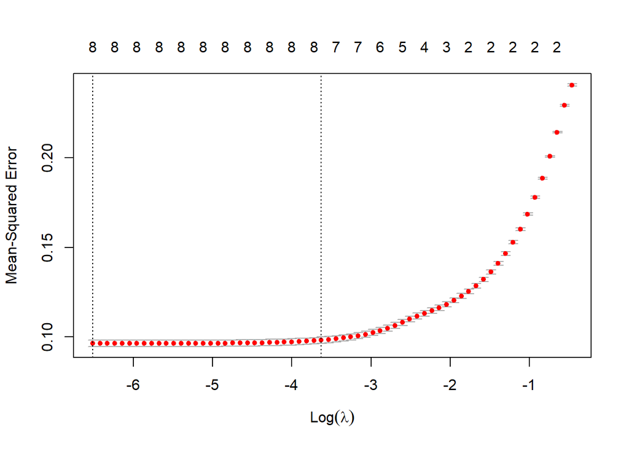

```r
# Prepare data
x <- model.matrix(IsDefender ~ . - 1, data = train_data)
y <- train_data$IsDefender

#fit elastic net model
cv_glmnet <- cv.glmnet(x, y, alpha = 0.5)  # alpha=1 for Lasso, alpha=0 for Ridge
plot(cv_glmnet)
```

```r
# Get coefficients at the optimal lambda
best_lambda <- cv_glmnet$lambda.min
coef(cv_glmnet, s = best_lambda)
```

```
## 9 x 1 sparse Matrix of class "dgCMatrix"
##                        s1
## (Intercept) -0.6826457679
## pace         0.0104528383
## shooting    -0.0130999182
## passing     -0.0093019099
## dribbling   -0.0008027612
## defending    0.0153827265
## physic       0.0024794765
## height_cm    0.0018416600
## weight_kg    0.0048791738
```

## Coefficients from Lasso Model

The Lasso model (alpha = 1) coefficients are quite similar to those from the Elastic Net model. The biggest difference with Lasso is that it can set some coefficients exactly to zero, which isn’t happening with the variables shown here.

In both models, the defending attribute has the strongest positive association with being a defender, which is consistent with what you would expect in a soccer dataset: players with higher defending skills are more likely to be classified as defenders. Negative coefficients for shooting, passing, and dribbling suggest that players with higher abilities in these areas are less likely to be defenders, possibly because these skills are more critical for forwards and midfielders.

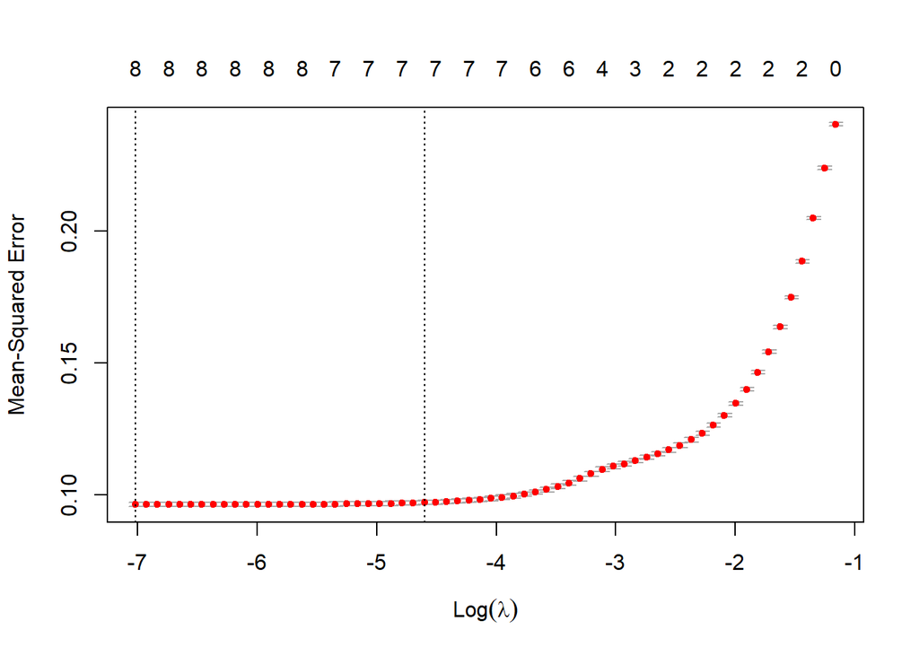

```r
# Fit Lasso model
cv_glmnet <- cv.glmnet(x, y, alpha = 1)  # Set alpha to 1 for Lasso
plot(cv_glmnet)
```

```r
# Extract coefficients at the optimal lambda
best_lambda <- cv_glmnet$lambda.min
lasso_coefs <- coef(cv_glmnet, s = best_lambda)
print(lasso_coefs)
```

```
## 9 x 1 sparse Matrix of class "dgCMatrix"
##                        s1
## (Intercept) -0.6820311318
## pace         0.0104313324
## shooting    -0.0131044830
## passing     -0.0094186509
## dribbling   -0.0006537424
## defending    0.0154275424
## physic       0.0024352314
## height_cm    0.0018270110
## weight_kg    0.0049012166
```

1. **Defending Skills**: The `defending` attribute has the most substantial positive association with being a defender across both models. This finding is intuitive and confirms that this feature is likely the most important predictor for determining if a player is a defender.
2. **Offensive Skills**: Attributes typically associated with offensive skills, such as `shooting`, `passing`, and `dribbling`, are negatively associated with the likelihood of being a defender, which also aligns with domain knowledge of soccer.
3. **Physical Attributes**: `height_cm` and `weight_kg` have positive associations with being a defender, suggesting that larger physical size is a characteristic of defensive players in dataset.
4. **Sparse Model**: The Lasso model did not set any coefficients to zero, which means it did not exclude any predictors from the model based on the provided output.
5. **Model Selection**: The Elastic Net model combines the feature selection properties of Lasso with the shrinkage of Ridge. The blend has moderated the coefficients, and because no coefficients are zero, it suggests that all the features included might have some relationship with the outcome.

```r
# Logistic Regression Model
logit_model <- glm(IsDefender ~ ., data = train_data, family = "binomial")
logit_predictions <- predict(logit_model, newdata = test_data, type = "response")
logit_predicted_classes <- ifelse(logit_predictions > 0.5, 1, 0)
# Convert both predicted classes and actual classes to factors with the same levels
logit_predicted_classes <- factor(logit_predicted_classes, levels = c(0, 1))
test_data$IsDefender <- factor(test_data$IsDefender, levels = c(0, 1))
# Create confusion matrix
logit_confMatrix <- confusionMatrix(logit_predicted_classes, test_data$IsDefender)
print(logit_confMatrix)
```

```
## Confusion Matrix and Statistics
##
##           Reference
## Prediction    0    1
##          0 1774  148
##          1  187 1116
##
##                Accuracy : 0.8961
##                  95% CI : (0.8851, 0.9064)
##     No Information Rate : 0.6081
##     P-Value [Acc > NIR] : < 2e-16
##
##                   Kappa : 0.7833
##
##  Mcnemar's Test P-Value : 0.03788
##
##             Sensitivity : 0.9046
##             Specificity : 0.8829
##          Pos Pred Value : 0.9230
##          Neg Pred Value : 0.8565
##              Prevalence : 0.6081
##          Detection Rate : 0.5501
##    Detection Prevalence : 0.5960
##       Balanced Accuracy : 0.8938
##
##        'Positive' Class : 0
##
```

```r
# Extract metrics from the confusion matrix
logit_accuracy <- logit_confMatrix$overall['Accuracy']
logit_precision <- logit_confMatrix$byClass['Precision']
logit_recall <- logit_confMatrix$byClass['Sensitivity']
logit_F1 <- 2 * (logit_precision * logit_recall) / (logit_precision + logit_recall)

# Print the metrics
print(paste("Accuracy:", logit_accuracy))
```

```
## [1] "Accuracy: 0.896124031007752"
```

```r
print(paste("Precision:", logit_precision))
```

```
## [1] "Precision: 0.922996878251821"
```

```r
print(paste("Recall (Sensitivity):", logit_recall))
```

```
## [1] "Recall (Sensitivity): 0.90464048954615"
```

```r
print(paste("F1 Score:", logit_F1))
```

```
## [1] "F1 Score: 0.913726500128766"
```

### Conclusion

The logistic regression model shows high accuracy and a strong ability to discriminate between defenders and non-defenders. The Kappa statistic indicates a substantial agreement, and the model’s balance between sensitivity and specificity is good. The accuracy is much higher than the No Information Rate, which suggests that the model has predictive power beyond random guessing.

Overall, the model seems to perform well, but the final assessment should consider the specific cost of false positives versus false negatives in the practical application where the model will be used.

```r
players$IsDefender <- ifelse(grepl("B", players$player_positions), 1, 0)

# Exclude offensive features: 'pace', 'shooting', 'passing', 'dribbling'
predictors <- c("defending", "physic", "height_cm", "weight_kg")

# Prepare the dataset (ensure that you have no missing values in the predictors and the target variable)
classification_data <- players %>%
  select(IsDefender, all_of(predictors)) %>%
  na.omit()

# Create reduced training and testing sets
set.seed(123) # for reproducibility
training_rows <- createDataPartition(classification_data$IsDefender, p = 0.8, list = FALSE)
reduced_train_data <- classification_data[training_rows, ]
reduced_test_data <- classification_data[-training_rows, ]
```

# Fit Logistic Regression Model with reduced predictors

```r
#
logit_model <- glm(IsDefender ~ ., data = reduced_train_data, family = "binomial")
logit_predictions <- predict(logit_model, newdata = reduced_test_data, type = "response")
logit_predicted_classes <- ifelse(logit_predictions > 0.5, 1, 0)
# Convert both predicted classes and actual classes to factors with the same levels
logit_predicted_classes <- factor(logit_predicted_classes, levels = c(0, 1))
reduced_test_data$IsDefender <- factor(reduced_test_data$IsDefender, levels = c(0, 1))
# Create confusion matrix
logit_confMatrix <- confusionMatrix(logit_predicted_classes, reduced_test_data$IsDefender)
print(logit_confMatrix)
```

```
## Confusion Matrix and Statistics
##
##           Reference
## Prediction    0    1
##          0 1558  272
##          1  403  992
##
##                Accuracy : 0.7907
##                  95% CI : (0.7762, 0.8046)
##     No Information Rate : 0.6081
##     P-Value [Acc > NIR] : < 2.2e-16
##
##                   Kappa : 0.5688
##
##  Mcnemar's Test P-Value : 5.624e-07
##
##             Sensitivity : 0.7945
##             Specificity : 0.7848
##          Pos Pred Value : 0.8514
##          Neg Pred Value : 0.7111
##              Prevalence : 0.6081
##          Detection Rate : 0.4831
##    Detection Prevalence : 0.5674
##       Balanced Accuracy : 0.7897
##
##        'Positive' Class : 0
##
```

### Conclusion

The removal of offensive features from the model has resulted in a noticeable decrease in all performance metrics. The most significant reductions are in negative predictive value and accuracy. This indicates that offensive attributes such as ‘pace’, ‘shooting’, ‘passing’, and ‘dribbling’ contribute valuable information for predicting whether a player is a defender and that their exclusion impairs the model’s predictive ability.

From these observations, we can conclude that while simplifying the model can have benefits, such as improved interpretability and potentially reduced overfitting, it is important to carefully consider which features to exclude. Features that may seem less important could still be providing essential information for the model, and their exclusion can negatively impact performance.

The results demonstrate the importance of including a comprehensive set of features that capture the full spectrum of influences on the target variable. For a nuanced decision like determining a player’s position, which can be influenced by a variety of factors, a more complex model with a richer feature set appears to provide better performance.

# Fit Logistic Regression Model on the full training data

```r
full_logit_model_train <- glm(IsDefender ~ ., data = train_data, family = "binomial")

# Predict on the training data
train_predictions <- predict(full_logit_model_train, newdata = train_data, type = "response")
train_pred_classes <- ifelse(train_predictions > 0.5, 1, 0)

# Convert predictions and actual classes to factors
train_pred_classes <- factor(train_pred_classes, levels = c(0, 1))
train_data$IsDefender <- factor(train_data$IsDefender, levels = c(0, 1))

# Create confusion matrix for the training data
train_confMatrix <- confusionMatrix(train_pred_classes, train_data$IsDefender)
print(train_confMatrix)
```

```
## Confusion Matrix and Statistics
##
##           Reference
## Prediction    0    1
##          0 6989  636
##          1  709 4569
##
##                Accuracy : 0.8958
##                  95% CI : (0.8904, 0.901)
##     No Information Rate : 0.5966
##     P-Value [Acc > NIR] : < 2e-16
##
##                   Kappa : 0.7839
##
##  Mcnemar's Test P-Value : 0.04962
##
##             Sensitivity : 0.9079
##             Specificity : 0.8778
##          Pos Pred Value : 0.9166
##          Neg Pred Value : 0.8657
##              Prevalence : 0.5966
##          Detection Rate : 0.5417
##    Detection Prevalence : 0.5909
##       Balanced Accuracy : 0.8929
##
##        'Positive' Class : 0
##
```

# Fit Logistic Regression Model on the full test data

```r
# Predict on the test data
test_predictions <- predict(full_logit_model_train, newdata = test_data, type = "response")
test_pred_classes <- ifelse(test_predictions > 0.5, 1, 0)

# Convert predictions and actual classes to factors
test_pred_classes <- factor(test_pred_classes, levels = c(0, 1))
test_data$IsDefender <- factor(test_data$IsDefender, levels = c(0, 1))

# Create confusion matrix for the test data
test_confMatrix <- confusionMatrix(test_pred_classes, test_data$IsDefender)
print(test_confMatrix)
```

```
## Confusion Matrix and Statistics
##
##           Reference
## Prediction    0    1
##          0 1774  148
##          1  187 1116
##
##                Accuracy : 0.8961
##                  95% CI : (0.8851, 0.9064)
##     No Information Rate : 0.6081
##     P-Value [Acc > NIR] : < 2e-16
##
##                   Kappa : 0.7833
##
##  Mcnemar's Test P-Value : 0.03788
##
##             Sensitivity : 0.9046
##             Specificity : 0.8829
##          Pos Pred Value : 0.9230
##          Neg Pred Value : 0.8565
##              Prevalence : 0.6081
##          Detection Rate : 0.5501
##    Detection Prevalence : 0.5960
##       Balanced Accuracy : 0.8938
##
##        'Positive' Class : 0
##
```

# Fit Logistic Regression Model on the subset

```r
# Example: Analyze subset where 'defending' is above average
subset_data <- train_data[train_data$defending > mean(train_data$defending), ]
subset_predictions <- predict(full_logit_model_train, newdata = subset_data, type = "response")
subset_pred_classes <- ifelse(subset_predictions > 0.5, 1, 0)
subset_pred_classes <- factor(subset_pred_classes, levels = c(0, 1))
subset_data$IsDefender <- factor(subset_data$IsDefender, levels = c(0, 1))

# Confusion matrix for the subset
subset_confMatrix <- confusionMatrix(subset_pred_classes, subset_data$IsDefender)
print(subset_confMatrix)
```

```
## Confusion Matrix and Statistics
##
##           Reference
## Prediction    0    1
##          0 1950  522
##          1  673 4389
##
##                Accuracy : 0.8414
##                  95% CI : (0.8329, 0.8496)
##     No Information Rate : 0.6518
##     P-Value [Acc > NIR] : < 2.2e-16
##
##                   Kappa : 0.6458
##
##  Mcnemar's Test P-Value : 1.43e-05
##
##             Sensitivity : 0.7434
##             Specificity : 0.8937
##          Pos Pred Value : 0.7888
##          Neg Pred Value : 0.8670
##              Prevalence : 0.3482
##          Detection Rate : 0.2588
##    Detection Prevalence : 0.3281
##       Balanced Accuracy : 0.8186
##
##        'Positive' Class : 0
##
```

From the results provided, you have several sets of confusion matrices and corresponding statistics for different scenarios: the full model’s performance on the training data, on the test data, and on a subset of the training data where the ‘defending’ attribute is above average. Here’s how to interpret and compare these results:

### Comparing Results and Conclusions

1. **Generalization**: The model generalizes well from training to test data, showing minimal overfitting as the accuracy and other metrics are very consistent across these datasets.
2. **Subset Analysis**: The model’s performance drops in a subset of data where defending is above average. This could indicate that as defending values increase, other features might interact differently affecting the model’s ability to generalize within this context.
3. **Practical Implications**: The lower performance in the subset could suggest the need for more complex modeling techniques that can handle higher interactions or non-linearities, particularly for players with higher defending skills.

Overall, the results suggest that your model is robust and performs well under general conditions but may require adjustments or more sophisticated methods to handle data subsets where player attributes significantly deviate from the norm. It also underscores the importance of examining model performance across different data segments to ensure consistent reliability.

```r
# # Prepare your data if not already done
# # train_data, test_data
#
# # Set up cross-validation - sets up how the training process should handle cross-validation.
# train_control <- trainControl(
#   method = "cv",
#   number = 10,  # using 10-fold cross-validation
#   savePredictions = "final"
# )
#
# # Define the tuning grid
# k_values <- data.frame(k = seq(1, 50, by = 1))  # testing k from 1 to 30
#
# # Train the model
# set.seed(123)  # for reproducibility
#
# # This function does the heavy lifting by training a k-NN model for each k value in the defined grid and evaluating its performance using the specified cross-validation strategy.
# knn_results <- train(
#   x = train_data[, predictors, drop = FALSE],
#   y = train_data$IsDefender,
#   method = "knn",
#   # This parameter allows you to pass the range of k values you want to test.
#   tuneGrid = k_values,
#   trControl = train_control,
#   # "scale": This ensures that the feature scaling is performed, which is crucial for k-NN models because they rely on distance calculations.
#   preProcess = "scale"
# )
#
# # Print the best model's results
# print(knn_results)
# plot(knn_results)
```

```r
# Train k-Nearest Neighbors model
# Target variable is a factor for classification
train_data$IsDefender <- as.factor(train_data$IsDefender)

# Train k-Nearest Neighbors model with class probabilities
knn_fit <- knn3(x = train_data[, predictors, drop = FALSE], y = train_data$IsDefender, k = 35, prob = TRUE)

# Predict probabilities on the test set
# Note: Ensure that test_data contains the same predictors as train_data
knn_prob <- predict(knn_fit, newdata = test_data[, predictors, drop = FALSE], type = "prob")[,2]

# Convert probabilities to class predictions using a 0.5 threshold
knn_class_predictions <- ifelse(knn_prob > 0.5, "1", "0")

# Ensure the predictions are factors with the same levels as the test data target variable
knn_class_predictions <- factor(knn_class_predictions, levels = levels(train_data$IsDefender))

# Generate the confusion matrix
knn_confMatrix <- confusionMatrix(knn_class_predictions, test_data$IsDefender)

# Print the confusion matrix
print(knn_confMatrix)
```

```
## Confusion Matrix and Statistics
##
##           Reference
## Prediction    0    1
##          0 1491  231
##          1  470 1033
##
##                Accuracy : 0.7826
##                  95% CI : (0.768, 0.7968)
##     No Information Rate : 0.6081
##     P-Value [Acc > NIR] : < 2.2e-16
##
##                   Kappa : 0.5588
##
##  Mcnemar's Test P-Value : < 2.2e-16
##
##             Sensitivity : 0.7603
##             Specificity : 0.8172
##          Pos Pred Value : 0.8659
##          Neg Pred Value : 0.6873
##              Prevalence : 0.6081
##          Detection Rate : 0.4623
##    Detection Prevalence : 0.5340
##       Balanced Accuracy : 0.7888
##
##        'Positive' Class : 0
##
```

```r
# Extract metrics from the confusion matrix
knn_accuracy <- knn_confMatrix$overall['Accuracy']
knn_precision <- knn_confMatrix$byClass['Precision']
knn_recall <- knn_confMatrix$byClass['Sensitivity']
knn_F1 <- 2 * (knn_precision * knn_recall) / (knn_precision + knn_recall)

# Print the metrics
print(paste("k-NN Accuracy:", knn_accuracy))
```

```
## [1] "k-NN Accuracy: 0.782635658914729"
```

```r
print(paste("k-NN Precision:", knn_precision))
```

```
## [1] "k-NN Precision: 0.865853658536585"
```

```r
print(paste("k-NN Recall (Sensitivity):", knn_recall))
```

```
## [1] "k-NN Recall (Sensitivity): 0.760326364099949"
```

```r
print(paste("k-NN F1 Score:", knn_F1))
```

```
## [1] "k-NN F1 Score: 0.80966603312517"
```

```r
# Predict probabilities on the training set itself
knn_prob_train <- predict(knn_fit, newdata = train_data[, predictors, drop = FALSE], type = "prob")[,2]

# Convert probabilities to class predictions using a 0.5 threshold
knn_class_predictions <- ifelse(knn_prob_train > 0.5, "1", "0")

# Ensure the predictions are factors with the same levels as the training data target variable
knn_class_predictions <- factor(knn_class_predictions, levels = levels(train_data$IsDefender))

# Generate the confusion matrix on the training data
knn_train_confMatrix <- confusionMatrix(knn_class_predictions, train_data$IsDefender)

# Print the confusion matrix
print(knn_train_confMatrix)
```

```
## Confusion Matrix and Statistics
##
##           Reference
## Prediction    0    1
##          0 5868  815
##          1 1830 4390
##
##                Accuracy : 0.795
##                  95% CI : (0.7879, 0.8019)
##     No Information Rate : 0.5966
##     P-Value [Acc > NIR] : < 2.2e-16
##
##                   Kappa : 0.5872
##
##  Mcnemar's Test P-Value : < 2.2e-16
##
##             Sensitivity : 0.7623
##             Specificity : 0.8434
##          Pos Pred Value : 0.8780
##          Neg Pred Value : 0.7058
##              Prevalence : 0.5966
##          Detection Rate : 0.4548
##    Detection Prevalence : 0.5179
##       Balanced Accuracy : 0.8028
##
##        'Positive' Class : 0
##
```

To compare the performance of the k-Nearest Neighbors (k-NN) model on both the training and test datasets, you’ve provided confusion matrices and associated statistics from each dataset. Here’s a detailed comparison of these two performance outcomes:

### Overview

- **Test Data Results**: Performance measures when the model is used to predict data it has not seen during training.
- **Training Data Results**: Performance measures when the model is used to predict the data it was trained on, which typically shows how well the model fits the training data.

### Implications:

- **Generalization**: The similar performance metrics (though slightly better on training) suggest that the model generalizes reasonably well but could potentially be improved to reduce overfitting and enhance predictive performance on unseen data.
- **Model Tuning**: Consider tuning model parameters (like `k`) or using feature selection/engineering to potentially enhance model performance, especially on unseen data.
- **Further Evaluation**: It’s beneficial to look into other metrics such as F1-score, ROC curves, and AUC, especially for imbalance class scenarios, to gain a deeper understanding of model performance.

Overall, the k-NN model shows good performance, but like most models, it performs slightly better on training data. Your analysis should consider whether the slight decrease in performance on test data is acceptable based on your specific use case requirements.

1. It avoids the risks associated with a too-low k, such as noise and outlier sensitivity, which could compromise the model’s generalizability.
2. It prevents the complexity and potential computational burden that a too-high k would introduce, which might be unnecessary given the lack of significant accuracy gains.
3. It positions us in a ‘safe zone’ where the model is neither too simplistic to capture the nuances of the data nor too complex to be bogged down by noise.

Lastly, the selection of k=35 also demonstrates stability in the model’s performance. There’s no indication of overfitting, as we might expect if the accuracy started to decline with larger values of k. This balance between bias and variance, or simplicity and complexity, suggests that k=35 is a reasonable choice for our model, striking a good balance between accuracy and computational efficiency.

```r
# Train a Random Forest model with OOB error tracking
set.seed(123)
rf_model <- randomForest(IsDefender ~ ., data = train_data, importance = TRUE, ntree = 500, do.trace = 100, keep.forest = TRUE)
```

```
## ntree      OOB      1      2
##   100:  10.43%  8.12% 13.85%
##   200:  10.48%  8.20% 13.85%
##   300:  10.39%  8.14% 13.72%
##   400:  10.35%  8.05% 13.76%
##   500:  10.31%  8.02% 13.70%
```

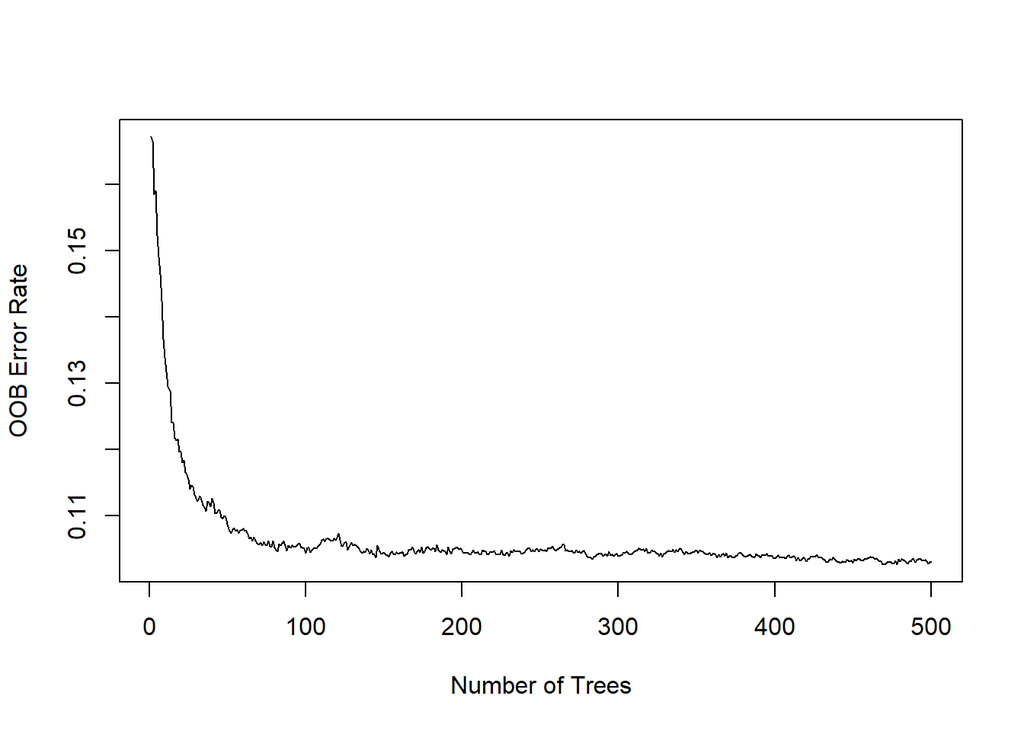

```r
# Plot OOB error
plot(rf_model$err.rate[, "OOB"], type = "l", xlab = "Number of Trees", ylab = "OOB Error Rate")
```

Out-of-Bag (OOB) error is a method of measuring the prediction error of random forests, gradient boosting, and other ensemble classifiers that bootstrap the data, i.e., sample the data with replacement. Here’s the process in brief:

1. **Bootstrap Sampling**: When building each tree, the algorithm samples from the original dataset with replacement, to create a bootstrap dataset. This bootstrap dataset is used to grow the tree. Because sampling is with replacement, some observations may be repeated in the bootstrap dataset while others are left out.
2. **OOB Instances**: The left-out observations that are not included in the bootstrap sample for creating a tree are known as OOB instances. Since these instances are not used in the construction of a particular tree, they can be used as a test set to assess the performance of that tree.
3. **Error Estimation**: For each tree, the OOB error is the prediction error calculated on the OOB instances. It’s like a built-in cross-validation method at each step of the ensemble model building.
4. **Ensemble OOB Error**: The overall OOB error for the forest is calculated by averaging the OOB errors across all trees in the ensemble.

OOB error provides a handy and unbiased estimate of the model accuracy without needing a separate validation set or cross-validation, which can be especially useful when the dataset is small.

The plot demonstrates the Out-of-Bag (OOB) error rate for a Random Forest model as a function of the number of trees included in the model. To interpret the plot and decide on the optimal number of trees, consider the following points:

1. **Sharp Decline**: At the beginning, as we start from a small number of trees, there is a significant decrease in the OOB error rate. This indicates that adding more trees initially leads to a substantial improvement in the model’s ability to predict accurately.
2. **Flattening Curve**: As the number of trees increases, the rate of decrease in the OOB error slows down and the curve begins to flatten. This indicates that each additional tree contributes less to improving the model’s performance.
3. **Stabilization Point**: Beyond a certain number of trees, the OOB error rate stabilizes and we see very minimal fluctuations. This suggests that the model has reached its performance limit given the current data and hyperparameters.
4. **Selection of Number of Trees**: The choice of the optimal number of trees should be where the OOB error rate has stabilized and before it plateaus completely to avoid unnecessary computation and potential overfitting. In this plot, around 100 trees could be a practical choice since the OOB error does not significantly improve after this point.
5. **Minimal Gains Beyond**: After approximately 100 trees, the gains from adding more trees are minimal. The OOB error rates between 100 and 500 trees are close, indicating that increasing the number of trees beyond 100 doesn’t lead to meaningful improvements in this case.

In conclusion, given the pattern observed in the OOB error rate plot, choosing 100 trees for the Random Forest model would likely be sufficient and computationally efficient while maintaining high predictive accuracy.

```r
# Fit the Random Forest model
rf_model <- randomForest(IsDefender ~ ., data = train_data, importance = TRUE, ntree = 100)

# Get the importance of predictors
importance <- importance(rf_model)
print(importance)
```

```
##                   0         1 MeanDecreaseAccuracy MeanDecreaseGini
## pace      44.656297 32.215954             53.43097         566.4279
## shooting  24.885519 24.431334             31.07476        1678.7898
## passing   16.868508 15.182059             25.28810         479.4165
## dribbling 18.837030  9.655391             19.47874         542.7663
## defending 57.015643 52.022179             68.00444        1883.8433
## physic     9.907031 13.897568             16.85676         471.0174
## height_cm  5.913589 19.376815             21.15593         305.6167
## weight_kg  8.649543 11.844949             14.97812         276.9885
```

```r
# Predict on the test data to get the probabilities
rf_prob <- predict(rf_model, newdata = test_data, type = "prob")[, "1"]

# Convert probabilities to binary class predictions using a 0.5 threshold
rf_predictions <- ifelse(rf_prob > 0.5, "1", "0")

# Convert rf_predictions to a factor with levels corresponding to the model's classes
rf_predictions <- factor(rf_predictions, levels = levels(train_data$IsDefender))

# Generate the confusion matrix
conf_mat <- confusionMatrix(rf_predictions, test_data$IsDefender)

# Print the confusion matrix and related statistics
print(conf_mat)
```

```
## Confusion Matrix and Statistics
##
##           Reference
## Prediction    0    1
##          0 1806  179
##          1  155 1085
##
##                Accuracy : 0.8964
##                  95% CI : (0.8854, 0.9067)
##     No Information Rate : 0.6081
##     P-Value [Acc > NIR] : <2e-16
##
##                   Kappa : 0.782
##
##  Mcnemar's Test P-Value : 0.2082
##
##             Sensitivity : 0.9210
##             Specificity : 0.8584
##          Pos Pred Value : 0.9098
##          Neg Pred Value : 0.8750
##              Prevalence : 0.6081
##          Detection Rate : 0.5600
##    Detection Prevalence : 0.6155
##       Balanced Accuracy : 0.8897
##
##        'Positive' Class : 0
##
```

```r
# Extract metrics from the confusion matrix
rf_accuracy <- conf_mat$overall['Accuracy']
rf_precision <- conf_mat$byClass['Precision']
rf_recall <- conf_mat$byClass['Sensitivity']
rf_F1 <- 2 * (rf_precision * rf_recall) / (rf_precision + rf_recall)

# Print the metrics
print(paste("Random Forest Accuracy:", rf_accuracy))
```

```
## [1] "Random Forest Accuracy: 0.896434108527132"
```

```r
print(paste("Random Forest Precision:", rf_precision))
```

```
## [1] "Random Forest Precision: 0.909823677581864"
```

```r
print(paste("Random Forest Recall (Sensitivity):", rf_recall))
```

```
## [1] "Random Forest Recall (Sensitivity): 0.9209586945436"
```

```r
print(paste("Random Forest F1 Score:", rf_F1))
```

```
## [1] "Random Forest F1 Score: 0.915357323872276"
```

The output you provided includes the feature importance scores from a Random Forest model and the performance metrics from a confusion matrix based on predictions made on the test data. Here’s a detailed explanation of each part of this output:

### Feature Importance

The `importance` function from the Random Forest model provides two types of metrics: - **MeanDecreaseAccuracy**: Indicates how much the accuracy of the model decreases when a feature is randomly permuted (shuffled). This metric reflects the impact of the feature on the model’s predictive accuracy. - **MeanDecreaseGini**: Represents the total decrease in node impurity (measured by the Gini index) that results from splits over that feature, averaged over all trees. A higher value indicates a more important feature.

```r
# Predict on the training data to get the probabilities
rf_prob_train <- predict(rf_model, newdata = train_data, type = "prob")[, "1"]

# Convert probabilities to binary class predictions using a 0.5 threshold
rf_predictions_train <- ifelse(rf_prob_train > 0.5, "1", "0")

# Ensure that train_data$IsDefender is a factor with levels as expected by the model
train_data$IsDefender <- factor(train_data$IsDefender, levels = levels(rf_model$y))

# Ensure that rf_predictions_train is a factor with the same levels as train_data$IsDefender
rf_predictions_train <- factor(rf_predictions_train, levels = levels(train_data$IsDefender))

# Generate the confusion matrix for the training data
conf_mat_train <- confusionMatrix(rf_predictions_train, train_data$IsDefender)

# Print the confusion matrix and related statistics for the training data
print(conf_mat_train)
```

```
## Confusion Matrix and Statistics
##
##           Reference
## Prediction    0    1
##          0 7698    1
##          1    0 5204
##
##                Accuracy : 0.9999
##                  95% CI : (0.9996, 1)
##     No Information Rate : 0.5966
##     P-Value [Acc > NIR] : <2e-16
##
##                   Kappa : 0.9998
##
##  Mcnemar's Test P-Value : 1
##
##             Sensitivity : 1.0000
##             Specificity : 0.9998
##          Pos Pred Value : 0.9999
##          Neg Pred Value : 1.0000
##              Prevalence : 0.5966
##          Detection Rate : 0.5966
##    Detection Prevalence : 0.5967
##       Balanced Accuracy : 0.9999
##
##        'Positive' Class : 0
##
```

To compare the model’s performance on the test data with its performance on the training data, we examine the confusion matrix statistics for both.

**On the Test Data:** - Accuracy: 89.64%, indicating the proportion of total correct predictions. - Kappa: 0.782, which measures the agreement between predicted and actual classifications, corrected for chance agreement. - Sensitivity: 92.10%, indicating the model’s ability to correctly identify the positive class. - Specificity: 85.84%, indicating the model’s ability to correctly identify the negative class. - The Positive Predictive Value (PPV) and Negative Predictive Value (NPV) are above 87%, suggesting good reliability in the predictions. - The Balanced Accuracy, which is the average of sensitivity and specificity, is at 88.97%, reflecting a good balance between true positive rate and true negative rate.

**On the Training Data:** - Accuracy: Almost perfect at 99.99%, indicating the model predicts nearly all training cases correctly. - Kappa: 0.9998, showing almost perfect agreement. - Sensitivity and Specificity are virtually 100%, which could indicate the model is overfitted to the training data. - PPV and NPV are 99.99% and 100%, respectively. - Balanced Accuracy is also nearly perfect at 99.99%.

**Conclusions:** - The Random Forest model performs exceptionally well on the training data, possibly too well, indicating that it may have overfitted to the training set. This is not uncommon with Random Forest models, especially when the default settings allow trees to grow without much constraint. - The model’s performance on the test data, while very good, is not as high as on the training data, which is expected due to the model being exposed to new, unseen data. - Despite the drop in performance metrics from training to testing, the results on the test data are still strong, indicating that the model has good generalization capabilities. - The relatively high values for Kappa, Sensitivity, Specificity, PPV, NPV, and Balanced Accuracy on the test data suggest that the model is robust and reliable in making predictions on new data.

In practice, if a model shows such high accuracy on the training data but lower on the test data, one might investigate further to fine-tune the model to avoid overfitting and improve generalization on unseen data. This can be done by tuning hyperparameters, pruning the trees, or incorporating more training data.